# DATA 606 Data Project Proposal

Calvin Wong

10/14/2018

### Data Preparation

```r
library(psych)
library(ggplot2)
df <-  read.csv(file = "https://raw.githubusercontent.com/fivethirtyeight/data/master/college-majors/grad-students.csv", header= TRUE)
df <- df[,c('Major_category', 'Major', 'Grad_total', 'Grad_employed', 'Grad_full_time_year_round', 'Grad_median')]
names(df) <- c('Category', 'Major', 'Total', 'Employed', 'Fulltime', 'Median_salary')
head(df)
```

```
##                              Category
## 1 Industrial Arts & Consumer Services
## 2                                Arts
## 3                            Business
## 4 Industrial Arts & Consumer Services
## 5             Computers & Mathematics
## 6                 Law & Public Policy
##                                    Major Total Employed Fulltime
## 1                  CONSTRUCTION SERVICES  9173     7098     6511
## 2      COMMERCIAL ART AND GRAPHIC DESIGN 53864    40492    29553
## 3                 HOSPITALITY MANAGEMENT 24417    18368    14784
## 4 COSMETOLOGY SERVICES AND CULINARY ARTS  5411     3590     2701
## 5             COMMUNICATION TECHNOLOGIES  9109     7512     5622
## 6                        COURT REPORTING  1542     1008      860
##   Median_salary
## 1         75000
## 2         60000
## 3         65000
## 4         47000
## 5         57000
## 6         75000
```

### Research question

**You should phrase your research question in a way that matches up with the scope of inference your dataset allows for.**

How monetarily viable are graduate degree types against each other?

### Data collection

**Describe the method of data collection.**

Every year, the U.S. Census Bureau contacts over 3.5 million households across the country to participate in the American Community Survey (ACS). The information that the Census Bureau collects helps to determine how more than $675 billion dollars of federal funding each year is spent on infrastructure and services. Through the ACS, data about jobs and occupations, educational attainment, veterans, whether people own or rent their home, and many other topics are available. The American Community Survey (ACS) Public Use Microdata Sample (PUMS) files are a set of untabulated records about individual people or housing units. The Census Bureau produces the PUMS files so that data users can create custom tables that are not available through pretabulated (or summary) ACS data products.

### Type of study

**What type of study is this (observational/experiment)?**

Observational

### Data Source

**If you collected the data, state self-collected. If not, provide a citation/link.**

This data is an excerpt from American Community Survey 2010-2012 Public Use Microdata Series produced by fivethirtyeight.com and located https://github.com/fivethirtyeight/data/blob/master/college-majors/grad-students.csv

Casselman, B. (2014, September 12). The Economic Guide To Picking A College Major. Retrieved October 18, 2018, from https://fivethirtyeight.com/features/the-economic-guide-to-picking-a-college-major/

### Dependent Variable

**What is the response variable? Is it quantitative or qualitative?**

Category and it is qualitative.

### Independent Variable

**You should have two independent variables, one quantitative and one qualitative.**

Major - Major type (Qualitative) Grad_median - Median earnings (Quantitative)

### Relevant summary statistics

**Provide summary statistics for each the variables. Also include appropriate visualizations related to your research question (e.g. scatter plot, boxplots, etc). This step requires the use of R, hence a code chunk is provided below. Insert more code chunks as needed.**

```r
describe(df$Median_salary)
```

```
##    vars   n     mean      sd median  trimmed     mad   min    max range
## X1    1 173 76755.78 16912.1  75000 75876.98 19273.8 47000 135000 88000
##    skew kurtosis     se
## X1 0.54     -0.2 1285.8
```

```r
describe(df$Employed)
```

```
##    vars   n     mean       sd median  trimmed      mad  min    max  range
## X1    1 173 94037.03 159723.9  28930 54204.07 32261.38 1008 915341 914333
##    skew kurtosis       se
## X1 2.95     9.36 12143.58
```

```r
as.data.frame(table(df$Category))
```

```
##                                   Var1 Freq
## 1      Agriculture & Natural Resources   10
## 2                                 Arts    8
## 3               Biology & Life Science   14
## 4                             Business   13
## 5          Communications & Journalism    4
## 6              Computers & Mathematics   11
## 7                            Education   16
## 8                          Engineering   29
## 9                               Health   12
## 10           Humanities & Liberal Arts   15
## 11 Industrial Arts & Consumer Services    7
## 12                   Interdisciplinary    1
## 13                 Law & Public Policy    5
## 14                   Physical Sciences   10
## 15            Psychology & Social Work    9
## 16                      Social Science    9
```

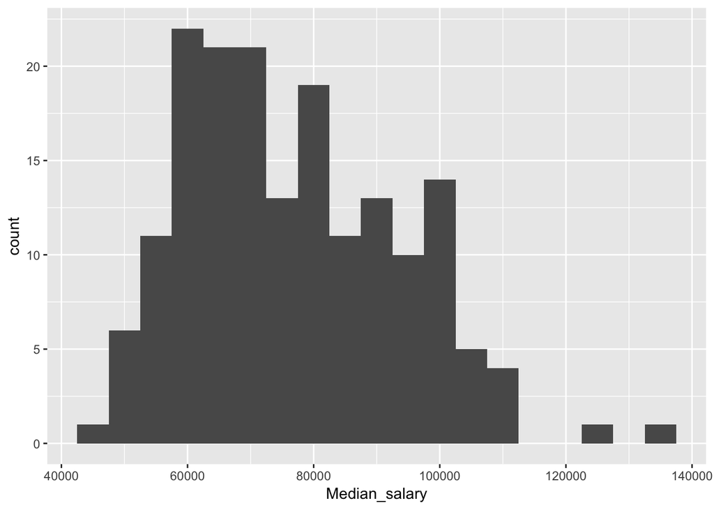

```r
ggplot(df, aes(x=Median_salary)) + geom_histogram(binwidth = 5000)
```

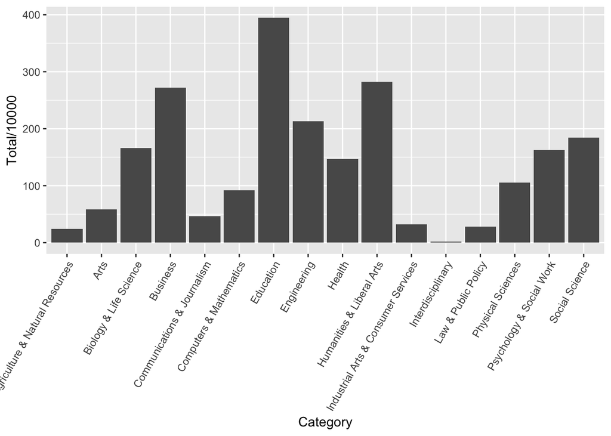

```r
ggplot(df, aes(x=Category, y=Total/10000) ) +
    geom_bar(stat="identity") +
    theme(axis.text.x = element_text(angle = 60, hjust = 1))
```